# The effect of fences on the multi-mode contact networks on Michigan farms

This analysis examines the effect of wildlife fences on the multi-mode contact networks in Michigan farms.

```python
# Load in needed modules
import numpy as np
import pymc3 as pm
from scipy.stats import stats
import matplotlib.pyplot as plt
import pandas as pd
import theano
import theano.tensor as tt
import seaborn as sns
import networkx as nx
from patsy import dmatrices
import contact
import importlib
importlib.reload(contact)
importlib.reload(pd)

# Default theano condition
# theano.config.compute_test_value = 'ignore'

sns.set_style("white")
plt.rcParams['figure.facecolor'] = "white"

colors = sns.color_palette()
```

## Load in the contact data for analysis

After loading the data, we exclude all individuals that had proximity loggers, but never had any type of contact over the course of the study. The results of the analysis are robust to dropping these individuals.

```python
# Load in formatted contact data
dat = pd.read_csv("../data/formatted/formatted_contact_data.csv")

# Load in unique contact data
unqids = pd.read_csv("../data/formatted/unique_contact_ids.csv", header=None).values.ravel()
unqids2 = np.unique(np.concatenate([dat.id1, dat.id2]))

# IDs that never had any contacts with troughs or otherwise despite being collared
nocontacts = set(unqids2) - set(unqids)

# Drop collared individuals that never had any contacts...only include active nodes
reddat = dat[~(dat.id1.isin(nocontacts) | dat.id2.isin(nocontacts))]
```

Reformat the data to consider three types of contact:

1. Direct contact
2. Indirect contact via stored feed
3. Indirect contact via non-stored feed

```python
# Melt by contact type
datdt = reddat.melt(id_vars=['pairID', 'season', 'fence', 'id1', 'spp1',
                          'startid1', 'endid1', 'id2', 'spp2', 'startid2',
                          'endid2', 'overlap_days', 'seasonal_overlap_days', 'farm'],
                 value_vars=['direct_contacts', 'indirect_contacts_stored_feed', 'indirect_contacts_other'],
                 var_name="contact_type", value_name="contacts")

datdt.loc[:, "contact_score"] = np.nan
datdt.loc[datdt.seasonal_overlap_days == 0, "contact_score"] = -1 # No overlap

datdt.loc[(datdt.seasonal_overlap_days != 0) & (datdt.contacts == 0), "contact_score"] = 0

datdt.loc[(datdt.seasonal_overlap_days != 0) &
          (datdt.contacts != 0) &
          (datdt.contact_type == "direct_contacts"), "contact_score"] = 1

datdt.loc[(datdt.seasonal_overlap_days != 0) &
          (datdt.contacts != 0) &
          (datdt.contact_type == "indirect_contacts_stored_feed"), "contact_score"] = 2

datdt.loc[(datdt.seasonal_overlap_days != 0) &
          (datdt.contacts != 0) &
          (datdt.contact_type == "indirect_contacts_other"), "contact_score"] = 3

# Remove data with fencing and not in spring because this data was not collected over the
# full season.
datdt = datdt[~(datdt.season.isin(['winter', "summer", "fall"]) & (datdt.fence == 1))]

# Only include three farms in the fence comparison. Farm Bev is excluded as no cows had active proximity loggers
# after fence installation.
datdt = datdt[datdt.farm.isin(['joe', 'pete', 'styma'])]
```

Summary of contact types in the spring before and after fence installation

-1 : No logger overlap

0 : No contact

1 : Direct contact

2 : Indirect contact via stored feed

3 : Indirect contact via other resources

```python
sp = datdt[datdt.season == "spring"]
sp.groupby(['farm', 'fence']).contact_score.value_counts()
```

```
farm   fence  contact_score
joe    0      -1.0             705
               0.0             460
               1.0              27
               2.0              20
               3.0               6
       1      -1.0             885
               0.0             298
               1.0              21
               2.0              11
               3.0               3
pete   0      -1.0             882
               0.0             446
               1.0              33
               2.0              28
               3.0               6
       1      -1.0             849
               0.0             511
               1.0              22
               2.0               9
               3.0               4
styma  0      -1.0             999
               0.0             347
               1.0              25
               2.0              18
               3.0               6
       1      -1.0             945
               0.0             412
               1.0              24
               2.0              13
               3.0               1
Name: contact_score, dtype: int64
```

```python
ids = np.unique(pd.concat([datdt.id1, datdt.id2]))
spps = ['D', 'R', 'O', 'cow']
for spp in spps:
    print(spp)
    print(np.sum(pd.Series(ids).str.find(spp) != -1))
```

```
D
14
R
16
O
22
cow
23
```

## Exploring the effect of fence on the contact networks

```python
# Drop bev from analysis
farmdt = datdt#[datdt.farm == "pete"]
animals = set(['moo', 'raccoon', 'opossum', 'deer'])

# Only include animal on animal interactions, direct or indirect
moddat = farmdt[(farmdt.contact_score > -1) & (farmdt.spp1.isin(animals) & farmdt.spp2.isin(animals))]

# Make species pair covariates
spppair = np.array(["_".join(np.sort([sp1, sp2])) for sp1, sp2 in zip(moddat.spp1, moddat.spp2)])
moddat = moddat.assign(spppair=spppair)

# Make design matrices. Different design matrices for different types of contact
_, Xmat1 = dmatrices("contact_score ~ " + " + ".join(["C(spppair)",
                                                  "standardize(seasonal_overlap_days)",
                                                  "C(season)",
                                                   "fence",
                                                   "C(farm) + fence:C(farm)"]),
                                        moddat, return_type="dataframe")

_, Xmat2 = dmatrices("contact_score ~ " + " + ".join(["C(spppair)",
                                                  "standardize(seasonal_overlap_days)",
                                                  "C(season)",
                                                   "fence",
                                                   "C(farm) + fence:C(farm)"]),
                                        moddat, return_type="dataframe")

# Response variable as a multinomial vector
Yres = pd.get_dummies(moddat.contact_score)


fence_model = pm.Model()

with fence_model:

    # Transformed coefficients
    betad = pm.Normal('betad', mu=0, sd=2, shape=(Xmat1.shape[1], 1))
    betai_stored = pm.Normal('betai_stored', mu=0, sd=2, shape=(Xmat2.shape[1], 1))
    betai_other = pm.Normal('betai_other', mu=0, sd=2, shape=(Xmat1.shape[1], 1))

    # Softmax transformation with no contact as baseline
    etad = tt.exp(tt.dot(Xmat1, betad))
    etai_stored = tt.exp(tt.dot(Xmat2, betai_stored))
    etai_other = tt.exp(tt.dot(Xmat1, betai_other))

    # Calculate probabilities for multinomial model
    p_d = etad / (1 + etad + etai_stored + etai_other)
    pi_stored = etai_stored / (1 + etad + etai_stored + etai_other)
    pi_other = etai_other / (1 + etad + etai_stored + etai_other)
    pn = 1 - p_d - pi_stored - pi_other
    ps = tt.stack([pn, p_d, pi_stored, pi_other], axis=1).reshape((len(Yres.values), 4)) # Stack column-wise

    #print(ps.tag.test_value.shape)
    #print(betaD.tag.test_value.shape)
    #print(p_d.tag.test_value.shape)
    #print(p_i.tag.test_value.shape)
    #print(p_n.tag.test_value.shape)

    Y_obs = pm.Multinomial("Y_obs", n=1, p=ps, observed=Yres.values)

    fit = pm.sample(draws=3000, chains=3, init="advi", nuts_kwargs={'target_accept': 0.9})
```

### Fit the full random effects model with an effect of fence

```python
# Drop bev from analysis
importlib.reload(contact)
farmdt = datdt
animals = set(['moo', 'raccoon', 'opossum', 'deer'])

# Only include animal on animal interactions, direct or indirect
moddat = farmdt[(farmdt.contact_score > -1) & (farmdt.spp1.isin(animals) & farmdt.spp2.isin(animals))]

# Make species pair covariates
spppair = np.array(["_".join(np.sort([sp1, sp2])) for sp1, sp2 in zip(moddat.spp1, moddat.spp2)])
moddat = moddat.assign(spppair=spppair)

# Make design matrices. Different design matrices for different types of contact

# Note: removing  C(spppair):C(farm) gives identical fence results and drastically speeds up
# convergence.
_, Xmat1 = dmatrices("contact_score ~ " + " + ".join(["C(spppair) + C(spppair):C(farm)",
                                                  "standardize(seasonal_overlap_days)",
                                                  "C(season)",
                                                   "fence",
                                                   "C(farm) + fence:C(farm)"]),
                                        moddat, return_type="dataframe")

_, Xmat2 = dmatrices("contact_score ~ " + " + ".join(["C(spppair) + C(spppair):C(farm)",
                                                  "standardize(seasonal_overlap_days)",
                                                  "C(season)",
                                                   "fence",
                                                   "C(farm) + fence:C(farm)"]),
                                        moddat, return_type="dataframe")

Xmat1_shared = theano.shared(Xmat1.values)
Xmat2_shared = theano.shared(Xmat2.values)

# Response variable as a multinomial vector
Yres = pd.get_dummies(moddat.contact_score)

fullids = pd.concat([moddat.id1, moddat.id2])
a1, lookup = contact.coerce_index(moddat.id1, fullids)
a2, _ = contact.coerce_index(moddat.id2, fullids)
num_ids = len(fullids.unique())

# Generate fence model
fence_model = contact.random_effects_model2_stored_feed(Xmat1_shared, Xmat1_shared, Xmat1_shared, Yres, a1, a2)

with fence_model:
    fence_fit =  pm.sample(draws=3000, chains=3, init="advi", nuts_kwargs={'target_accept': 0.9})
```

As suggested by Reviewer 1, try including a deer and "other"-wildlife effect of fence. That way we won't have to distinguish between raccoons and opossums (which we don't have much power to do), but can still try to identify an effect of fencing on deer.

```python
# Drop bev from analysis
importlib.reload(contact)
farmdt = datdt
animals = set(['moo', 'raccoon', 'opossum', 'deer'])

# Only include animal on animal interactions, direct or indirect
moddat = farmdt[(farmdt.contact_score > -1) & (farmdt.spp1.isin(animals) & farmdt.spp2.isin(animals))]

# Make species pair covariates
spppair = np.array(["_".join(np.sort([sp1, sp2])) for sp1, sp2 in zip(moddat.spp1, moddat.spp2)])
moddat = moddat.assign(spppair=spppair)

# Make deer-other covariates. If interaction has deer assign 1 otherwise 0.
deerind = (moddat.spppair.str.find("deer") != -1).astype(np.int)
moddat = moddat.assign(whitetail=deerind)

# Make design matrices. Different design matrices for different types of contact

# Note: removing C(spppair):C(farm) gives identical fence results and drastically speeds up
# convergence.
_, Xmat1_wt = dmatrices("contact_score ~ " + " + ".join(["C(spppair) + C(spppair):C(farm)",
                                                  "standardize(seasonal_overlap_days)",
                                                  "C(season)",
                                                   "fence",
                                                   "C(farm) + fence:C(farm)"]),
                                        moddat, return_type="dataframe")

# Just include an effect of whitetail on fence with stored feed.
_, Xmat2_wt = dmatrices("contact_score ~ " + " + ".join(["C(spppair) + C(spppair):C(farm)",
                                                  "standardize(seasonal_overlap_days)",
                                                  "C(season)",
                                                  "fence + fence:whitetail",
                                                  "C(farm) + fence:C(farm) + fence:whitetail:C(farm)"]),
                                        moddat, return_type="dataframe")

Xmat1_shared_wt = theano.shared(Xmat1_wt.values)
Xmat2_shared_wt = theano.shared(Xmat2_wt.values)

# Response variable as a multinomial vector
Yres = pd.get_dummies(moddat.contact_score)

fullids = pd.concat([moddat.id1, moddat.id2])
a1, lookup = contact.coerce_index(moddat.id1, fullids)
a2, _ = contact.coerce_index(moddat.id2, fullids)
num_ids = len(fullids.unique())

# Generate fence model
fence_model_wt = contact.random_effects_model2_stored_feed(Xmat1_shared_wt, Xmat2_shared_wt, Xmat1_shared_wt, Yres, a1, a2)

with fence_model_wt:
    fence_fit_wt =  pm.sample(draws=3000, chains=3, init="advi", nuts_kwargs={'target_accept': 0.9})
```

## Examine model convergence

```python
res = pm.summary(fence_fit)

# Any R_hat > 1.05?
np.any(res.Rhat > 1.05)
```

```
False
```

```python
# Fence model with deer specific effect
res = pm.summary(fence_fit_wt)

# Any R_hat > 1.05?
np.any(res.Rhat > 1.05)
```

```
False
```

```
array([[<matplotlib.axes._subplots.AxesSubplot object at 0x1c276b4b38>,
      dtype=object)
```

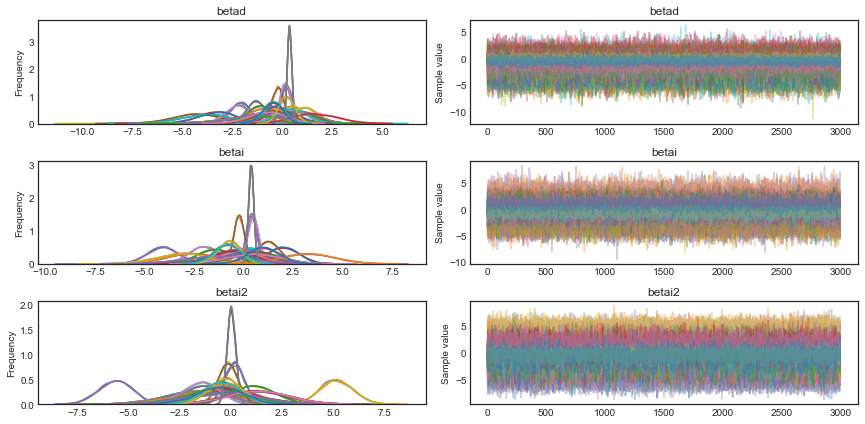

```python
# Look at traceplots
pm.traceplot(fence_fit, varnames=['betad', 'betai', 'betai2'])
```

```
array([[<matplotlib.axes._subplots.AxesSubplot object at 0x1c212f0978>,
      dtype=object)
```

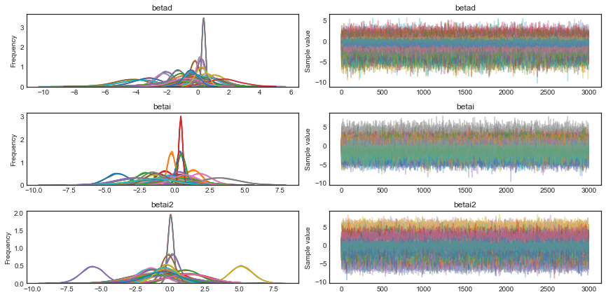

```python
# Look at traceplots
pm.traceplot(fence_fit_wt, varnames=['betad', 'betai', 'betai2'])
```

```python
pm.compare({fence_model: fence_fit, fence_model_wt: fence_fit_wt})
```

|  | WAIC | pWAIC | dWAIC | weight | SE | dSE | var_warn |
| --- | --- | --- | --- | --- | --- | --- | --- |
| 1 | 2775.7 | 140.02 | 0 | 1 | 91.75 | 0 | 1 |
| 0 | 2783.92 | 138.84 | 8.22 | 0 | 92.3 | 5.62 | 1 |

```python
fence_fit_wt['betai'].shape
```

```
(9000, 40, 1)
```

```python
fence_fit['betai'].shape
```

```
(9000, 37, 1)
```

```python
pm.summary(fence_fit_wt)
```

## Plot the effect of fence on different farms for all contact types

```
joe, -0.5393050550530846, 0.2465074726920204, 1.0113503078315793
pete, -1.0350396187178927, -0.1879221227607118, 0.6231362438577664
styma, -1.0359340752860475, -0.21178351167153753, 0.5556550784950998
joe, -1.8678253075858895, -0.7061419013519392, 0.37313399259283353
pete, -2.482626500649988, -1.4500893020329904, -0.4878273837600833
styma, -0.9986284867935106, 0.30287434942915203, 1.5585520230947807
joe, -1.7909453427102469, -0.2668370284533732, 1.1453812575368407
pete, -2.1601800513895038, -0.6975828811094227, 0.6276850267949159
styma, -3.066252301149883, -0.7587127345880122, 1.0026646774914887
```

```
Text(-0.05,1.05,'A.')
```

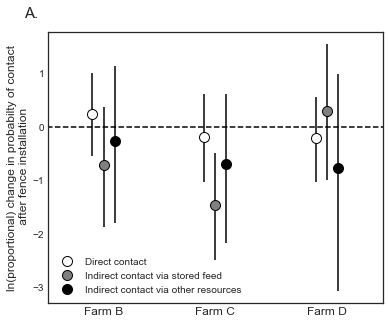

```python
fig, ax = plt.subplots(1, 1, figsize=(6, 5), sharey=True)

letters = ['A.', 'B.', "C."]

fit = fence_fit

contact_type = ['betad', 'betai', 'betai2']
cols = [Xmat1.columns, Xmat1.columns, Xmat1.columns]
plusminus = [-0.005, 0.005]
labels = ['Direct contact', 'Indirect contact via stored feed', 'Indirect contact via other resources']
nms = ['joe', 'pete', 'styma']
farmid = {'bev': "Farm A", 'joe': 'Farm B', 'pete': 'Farm C', 'styma': 'Farm D'}

handles = []
mean_probs = {}
probs_fence = []
probs_nofence = []

# Make a plot for both direct and indirect interactions
for j, ct in enumerate(contact_type):

    mean_probs[ct] = {}
    betad = fit[ct]
    betad = betad.reshape(betad.shape[0], betad.shape[1])
    intnames = cols[j]

    # Extract the farm and fence coefficients
    fenceind = pd.Series(intnames).str.find("fence") != -1
    fencenms = np.array(intnames)[fenceind.values]

    # Compute the effect of fence for each farm
    fencecoef = betad[:, fenceind.values]
    base = fencecoef[:, 0]
    other = fencecoef[:, 1:]
    additive = np.concatenate([base[:, np.newaxis], base[:, np.newaxis] + other], axis=1)

    probs_fence.append(np.exp(additive))

pms = [-0.1, 0, 0.1]
colors = ['white', 'gray', 'black']
for j in range(3):

    #
    coefs = pd.DataFrame(np.log(probs_fence[j]), columns=nms)
    xvals = range(3)

    for m, col in enumerate(coefs.columns):
        vals = coefs[col].values
        lower, med, upper = stats.scoreatpercentile(vals, (2.5, 50, 97.5))
        print("{0}, {1}, {2}, {3}".format(col, lower, med, upper))

        ax.errorbar(xvals[m] + pms[j], med, yerr=[[med - lower], [upper - med]], marker='o',
                                markersize=10, color=colors[j], ecolor="black", markeredgecolor="black")

    #sns.violinplot('variable', 'value', data=coefs.melt(), ax=axes[j])
ax.set_xticks(xvals)
ax.hlines(0, -2, 4, linestyle="--")
ax.set_xlabel("", size=12)
ax.set_xticklabels([farmid[c] for c in coefs.columns], size=12)


ax.set_ylabel("ln(proportional) change in probabilty of contact\n after fence installation",
                      size=12)
#ax.set_title(labels[j])
#ax.text(-0.1, 1.05, letters[j], ha="center", size=15, transform=axes[j].transAxes)
ax.set_xlim(-0.5, 2.5)

lines = [plt.Line2D([1], [1], color=colors[j], marker='o', linestyle="",
                        markeredgecolor="black", markersize=10) for j in range(3)]
ax.legend(lines, labels, loc="lower left")
ax.text(-0.05, 1.05, "A.", size=15, ha='center', transform=ax.transAxes)

#plt.savefig("../results/effect_of_fence.pdf", bbox_inches="tight")
```

```
joe, -0.5796441458414797, 0.21729901351349534, 0.9786157859809794
pete, -1.0503849459613193, -0.20095137751998607, 0.6033062772538537
styma, -1.0399054504551435, -0.22283664970042094, 0.5529968744631238
joe, -1.0905763004352351, 0.2815369969226829, 1.5837018279871014
pete, -2.0820302049140227, -0.974870300823766, -0.00577899781298282
styma, -0.4368288280058911, 1.0315512239671691, 2.4576985909703364
joe, -2.8040117033608007, -1.343474615228561, -0.060526972492420034
pete, -7.477660043346136, -4.11861380409002, -1.7253184320201673
styma, -5.553578604150872, -2.1057006344777047, 0.35117352404026003
joe, -1.7962432120158685, -0.2612701274205902, 1.1584623340873759
pete, -2.160487471180241, -0.6960396915190942, 0.6697670660066234
styma, -3.110662359788051, -0.7559352897920898, 1.0470720625502064
```

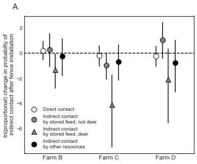

```python
fig, ax = plt.subplots(1, 1, figsize=(6, 5), sharey=True)

letters = ['A.', 'B.', "C."]

fit = fence_fit_wt

contact_type = ['betad', 'betai', 'betai', 'betai2']
cols = [Xmat1_wt.columns, Xmat2_wt.columns, Xmat2_wt.columns, Xmat1_wt.columns]
plusminus = [-0.005, 0.005]
labels = ['Direct contact', 'Indirect contact\nby stored feed, not deer', 'Indirect contact\nby stored feed, deer', 'Indirect contact\nby other resources']
nms = ['joe', 'pete', 'styma']
farmid = {'bev': "Farm A", 'joe': 'Farm B', 'pete': 'Farm C', 'styma': 'Farm D'}

handles = []
mean_probs = {}
probs_fence = []
probs_nofence = []

# Make a plot for both direct and indirect interactions
for j, ct in enumerate(contact_type):

    mean_probs[ct] = {}
    betad = fit[ct]
    betad = betad.reshape(betad.shape[0], betad.shape[1])
    intnames = cols[j]

    # Extract the farm and fence coefficients for non deer interactions
    fenceind = (pd.Series(intnames).str.find("fence") != -1) & (pd.Series(intnames).str.find("whitetail") == -1)

    # Compute the effect of fence for each farm
    fencecoef = betad[:, fenceind.values]
    base = fencecoef[:, 0]
    other = fencecoef[:, 1:]
    additive = np.concatenate([base[:, np.newaxis], base[:, np.newaxis] + other], axis=1)

    if j == 2:
        fenceind_wt = (pd.Series(intnames).str.find("fence") != -1) & (pd.Series(intnames).str.find("whitetail") != -1)

        fencecoef_wt = betad[:, fenceind_wt.values]
        base_wt = fencecoef_wt[:, 0]
        other_wt = fencecoef_wt[:, 1:]
        additive_wt = np.concatenate([base_wt[:, np.newaxis], base_wt[:, np.newaxis] + other_wt], axis=1)
        additive = additive + additive_wt

    probs_fence.append(np.exp(additive))

pms = [-0.17, -0.05, 0.05, 0.17]
colors = ['white', 'gray', 'gray', 'black']
mstyles = ['o', 'o', '^', 'o']
for j in range(4):

    #
    coefs = pd.DataFrame(np.log(probs_fence[j]), columns=nms)
    xvals = range(3)

    for m, col in enumerate(coefs.columns):
        vals = coefs[col].values
        lower, med, upper = stats.scoreatpercentile(vals, (2.5, 50, 97.5))
        print("{0}, {1}, {2}, {3}".format(col, lower, med, upper))

        ax.errorbar(xvals[m] + pms[j], med, yerr=[[med - lower], [upper - med]], marker=mstyles[j],
                                markersize=10, color=colors[j], ecolor="black", markeredgecolor="black")

    #sns.violinplot('variable', 'value', data=coefs.melt(), ax=axes[j])
ax.set_xticks(xvals)
ax.hlines(0, -2, 4, linestyle="--")
ax.set_xlabel("", size=12)
ax.set_xticklabels([farmid[c] for c in coefs.columns], size=12)


ax.set_ylabel("ln(proportional) change in probabilty of \n indirect contact after fence installation",
                      size=12)
#ax.set_title(labels[j])
#ax.text(-0.1, 1.05, letters[j], ha="center", size=15, transform=axes[j].transAxes)
ax.set_xlim(-0.5, 2.5)
#ax.set_ylim(-9, 1.5)

lines = [plt.Line2D([1], [1], color=colors[j], marker=mstyles[j], linestyle="",
                        markeredgecolor="black", markersize=10) for j in range(4)]
ax.legend(lines, labels, loc="lower left")
ax.text(-0.05, 1.05, "A.", size=15, ha='center', transform=ax.transAxes)

plt.savefig("../results/effect_of_fence.pdf", bbox_inches="tight")
```

## Simulate fence and no fence contact networks

Simulate how fence affects the structure of the contact network. Using the fitted model to simulate networks with and without a fence effect. Then comparing mean degree between these networks.

```python
import contact
import importlib
importlib.reload(contact)

# Simulate best fit model
model = fence_model_wt
fit = fence_fit_wt

X1 = Xmat1_shared_wt.eval()
X2 = Xmat2_shared_wt.eval()
```

```python
## Simulate a dataset with no fence

cols1 = Xmat1_wt.columns

Xd_df1 = pd.DataFrame(X1, columns=cols1)
ws_d1 = Xd_df1.copy()

cols2 = Xmat2_wt.columns

Xd_df2 = pd.DataFrame(X2, columns=cols2)
ws_d2 = Xd_df2.copy()


# Set all fence variables to 0
ws_d1.loc[:, ws_d1.filter(like="fence").columns] = 0
ws_d2.loc[:, ws_d2.filter(like="fence").columns] = 0

# Set all season variables to spring
for season in ['winter', 'summer', 'spring']:
    val = 0

    if season == 'spring':
        val = 1

    ws_d1['C(season)[T.{0}]'.format(season)] = val
    ws_d2['C(season)[T.{0}]'.format(season)] = val

# Set all seasonal_overlap variables to 0
ws_d1['standardize(seasonal_overlap_days)'] = 0
ws_d2['standardize(seasonal_overlap_days)'] = 0

# Predict all the data
Xmat1_shared_wt.set_value(ws_d1.values)
Xmat2_shared_wt.set_value(ws_d2.values)

Ysim_nofence = pm.sample_ppc(fit, model=model, samples=500)['Y_obs']
```

```python
## Simulate a dataset with all fence

# Set all fence variables to 1
ws_d1['fence'] = 1
ws_d2['fence'] = 1

# Reset fence-farm variables
for farm in ['pete', 'styma']:
    ws_d1.loc[ws_d1['C(farm)[T.{0}]'.format(farm)] == 1, 'fence:C(farm)[T.{0}]'.format(farm)] = 1
    ws_d2.loc[ws_d2['C(farm)[T.{0}]'.format(farm)] == 1, 'fence:C(farm)[T.{0}]'.format(farm)] = 1

# Reset fence-white tailed deer variables
ws_d2.loc[(moddat.spppair.str.find("deer") != -1).values, "fence:whitetail"] = 1

# Reset farm-specific white-tail values
for farm in ['pete', 'styma']:
    ws_d2.loc[np.bitwise_and((ws_d2['C(farm)[T.{0}]'.format(farm)] == 1).values,
                            (moddat.spppair.str.find("deer") != -1).values), 'fence:whitetail:C(farm)[T.{0}]'.format(farm)] = 1

Xmat1_shared_wt.set_value(ws_d1)
Xmat2_shared_wt.set_value(ws_d2)

# Predict all the data
Ysim_fence = pm.sample_ppc(fit, model=model, samples=500)['Y_obs']
```

```python
fencesim = []
for Ysim in [Ysim_fence, Ysim_nofence]:

    # Predicted contact list
    predcscore = [y[:, 0] == 0 for y in Ysim]

    pred_networks = {}
    moddat_dict = {}

    datdt_nobev = datdt[datdt.farm != "bev"]

    for p, farm in enumerate(datdt_nobev.farm.unique()):

        pred_networks[farm] = []

        # Clean the observed network
        redind = (datdt_nobev.contact_score > -1) & (datdt_nobev.spp1.isin(animals) & datdt_nobev.spp2.isin(animals))
        tdat = datdt_nobev[redind]

        # Include all seasons as we are considering all of the nodes in a farm in this simulation.
        seasonind = tdat.season.isin(['spring', 'winter', 'summer', 'fall'])
        farmind = tdat.farm == farm
        moddat = tdat[farmind & seasonind]
        spppair = np.array(["_".join(np.sort([sp1, sp2])) for sp1, sp2 in zip(moddat.spp1, moddat.spp2)])
        moddat = moddat.assign(spppair=spppair)

        # Build simulated network
        pnets = []
        for i in range(len(predcscore)):

            predc = moddat[predcscore[i][farmind & seasonind]]
            Gpred = nx.Graph()
            Gpred.add_nodes_from(np.unique(np.concatenate([moddat.id1, moddat.id2])))
            Gpred.add_edges_from(list(zip(predc.id1, predc.id2)))

            pnets.append(Gpred)

        # Save observed and predicted
        pred_networks[farm] = pnets
        moddat_dict[farm] = moddat

    fencesim.append(pred_networks)
```

```python
an_abbrev = ['O', 'R', 'cow', 'D']

for farm in moddat_dict.keys():
    allids = np.unique(pd.concat([moddat_dict[farm].id1, moddat_dict[farm].id2]))
    print(farm)
    print({an: np.sum(pd.Series(allids).str.find(an) != -1) for an in an_abbrev})
```

```
styma
{'O': 5, 'R': 7, 'cow': 8, 'D': 4}
joe
{'O': 9, 'R': 4, 'cow': 7, 'D': 4}
pete
{'O': 8, 'R': 5, 'cow': 8, 'D': 6}
```

```python
import importlib
importlib.reload(contact)
# Calculate and plot observed statistics
fencenm = ['After fence', 'Before fence']

predfence = []
for i, pn in enumerate(fencesim):

    networkstats = {}

    for farm in pn.keys():

        Gpred = pn[farm]

        # Calculate predicted and observed stats for networks
        predstats = pd.DataFrame([contact.network_stats(G, net_stats=['mean_degree', 'mean_betweenness']) for G in Gpred]).melt(var_name="stat")

        predstats.loc[:, 'farm'] = farm

        networkstats[farm] = predstats

    preddt = pd.concat([pred for farm, pred in networkstats.items()]).assign(fence=fencenm[i])
    predfence.append(preddt)

fencedt = pd.concat(predfence)
```

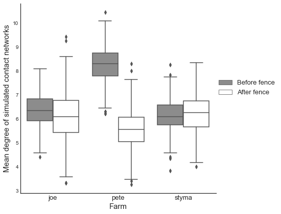

```python
meandt = fencedt[fencedt.stat == "mean_degree"]

fact = sns.factorplot(x="farm", y="value", hue='fence', col='stat', hue_order=['Before fence', 'After fence'],
                      data=meandt,kind='box',
                      sharey=False, sharex=False, order=np.sort(fencedt.farm.unique()),
                      size=6, legend=False, palette=['#8c8c8c', 'white'])
fact.ax.set_ylabel("Mean degree of simulated contact networks", size=15)
fact.ax.set_xlabel("Farm", size=15)
fact.ax.set_xticklabels(fact.ax.get_xticklabels(), size=13)
fact.ax.set_title("")
fact.ax.legend(loc=(1, 0.5), prop={'size': 13})
#plt.savefig("../results/mean_degree.pdf", bbox_inches="tight")
```

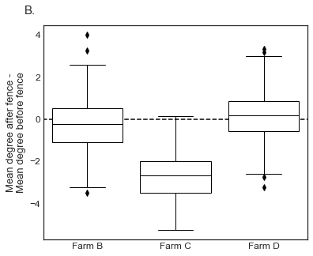

```python
res = (meandt.groupby(['farm']).apply(lambda x: x[x.fence == "After fence"]['value'] - x[x.fence == "Before fence"]['value']).T
        .reset_index(drop=True))#.drop(columns=['value']).T)

fig, ax = plt.subplots(1, 1, figsize=(6, 5))
sns.boxplot(x="farm", y="value", data=res.melt(), color="white", linewidth=1, ax=ax)
ax.set_ylabel("Mean degree after fence -\nMean degree before fence", size=13)
ax.tick_params(labelsize=12)
ax.set_xlabel("")
ax.set_xticklabels([farmid[a.get_text()] for a in list(ax.get_xticklabels())])
ax.hlines(0, -2, 4, linestyle='--', color='black', zorder=-1)
ax.text(-0.05, 1.05, "B.", size=15, ha='center', transform=ax.transAxes)

for p in ax.artists:
    p.set_edgecolor('black')

for l in ax.lines:
    l.set_color('black')
    l.set_mec('black')
    l.set_mfc('black')
plt.savefig("../results/fence_effect_mean_degree.pdf")
```